# DM06

**演習では，他人のデバイスに触らない．自分のデバイスを，他人に触らせない．**

**新しいノートブックは作らない．**前回作業したノートブックは，Google Driveの「マイドライブ/Colab Notebooks」に保存されているはず．それを開いて再開する．

結果を提示しているのは，計算が正しいことを確認してもらうためである．結果の形式を完全に同じにする必要はない．

## 1 準備

```
!pip install japanize_matplotlib | tail -n 1
```

使用するパッケージを読み込み，訓練データへの当てはまりの良さの指標であるRMSE（訓練）を求める関数`TRAIN_RMSE`と，予測性能の指標である $\displaystyle\sqrt{\mathrm{PRESS}/n}$ を求める関数`CV_RMSE`を定義する．

```python
import japanize_matplotlib
import numpy as np
import pandas as pd
import seaborn as sns
import statsmodels.api as sm
from sklearn import metrics
from sklearn.compose import ColumnTransformer
from sklearn.linear_model import LinearRegression
from sklearn.model_selection import cross_val_predict, cross_val_score, GridSearchCV, LeaveOneOut
from sklearn.neighbors import KNeighborsRegressor
from sklearn.pipeline import Pipeline
from sklearn.preprocessing import OneHotEncoder, OrdinalEncoder, PolynomialFeatures, StandardScaler
from sympy import *

def TRAIN_RMSE(model, X, y):
  model.fit(X, y)
  y_ = model.predict(X)
  return metrics.root_mean_squared_error(y, y_)

def CV_RMSE(model, X, y):
  return (-cross_val_score(model, X, y, cv=LeaveOneOut(), scoring='neg_mean_squared_error')).mean()**0.5
```

### 1.1 データの変換

入力変数を変換する方法を紹介する．

- 標準化
- べき乗
- ワンホットエンコーディング
- オーディナルエンコーディング

次のデータを使って説明する．

```python
data = pd.DataFrame({'p': [1, 2, 3], 'q': ['high', 'low', 'mid']})
data
```

```
##    p     q
## 0  1  high
## 1  2   low
## 2  3   mid
```

#### 1.1.1 標準化（教科書5.2.1項）

変数`p`を標準化する．

```python
f = StandardScaler()
result = f.fit_transform(data[['p']])
result
```

```
## array([[-1.22474487],
##        [ 0.        ],
##        [ 1.22474487]])
```

結果を見やすくする．

```python
pd.DataFrame(result, columns=f.get_feature_names_out(['p']))
```

```
##           p
## 0 -1.224745
## 1  0.000000
## 2  1.224745
```

#### 1.1.2 べき乗

```python
f = PolynomialFeatures(degree=3, include_bias=False)
result = f.fit_transform(data[['p']])
result
```

```
## array([[ 1.,  1.,  1.],
##        [ 2.,  4.,  8.],
##        [ 3.,  9., 27.]])
```

結果を見やすくする．

```python
pd.DataFrame(result, columns=f.get_feature_names_out(['p']))
```

```
##      p  p^2   p^3
## 0  1.0  1.0   1.0
## 1  2.0  4.0   8.0
## 2  3.0  9.0  27.0
```

#### 1.1.3 ワンホットエンコーディング（教科書5.2.2，5.2.3項）

`drop='first'`は冗長性をなくすための，`handle_unknown='ignore'`は不明な値をエラーにしないためのオプション。補足：オプション`drop='first'`は線形回帰分析では付けた方がよいが，他の手法では付けない方がよい結果になることもある（調べてみないとわからない）。

```python
f = OneHotEncoder(drop='first', handle_unknown='ignore')
result = f.fit_transform(data[['q']]).toarray()
result
```

```
## array([[0., 0.],
##        [1., 0.],
##        [0., 1.]])
```

結果を見やすくする．

```python
pd.DataFrame(result, columns=f.get_feature_names_out(['q']))
```

```
##    q_low  q_mid
## 0    0.0    0.0
## 1    1.0    0.0
## 2    0.0    1.0
```

#### 1.1.4 オーディナルエンコーディング

```python
f = OrdinalEncoder(categories=[['high', 'mid', 'low']])
result = f.fit_transform(data[['q']])
result
```

```
## array([[0.],
##        [2.],
##        [1.]])
```

結果を見やすくする．

```python
pd.DataFrame(result, columns=f.get_feature_names_out(['q']))
```

```
##      q
## 0  0.0
## 1  2.0
## 2  1.0
```

### 1.2 訓練への組み込み方

```python
ss = StandardScaler()
pf = PolynomialFeatures(degree=次数, include_bias=False)
oh = OneHotEncoder(drop='first', handle_unknown='ignore')
oe = OrdinaOrdinalEncoder(categories=カテゴリのリスト)
pt = 'passthrough' # そのまま使うことを示す文字列．

# 全てのラベルについて記述する場合
ct = ColumnTransformer([
    ('ss', ss, 対象のラベルのリスト), # 標準化
    ('pf', pf, 対象のラベルのリスト), # べき乗
    ('oh', oe, 対象のラベルのリスト), # ワンホットエンコーディング
    ('oe', oe, 対象のラベルのリスト), # オーディナルエンコーディング
    ('pt', pt, 対象のラベルのリスト), # そのまま
    ], remainder = 'drop')            # 他は使わない．

# 変換する変数についてのみ記述する場合
ct = ColumnTransformer([
    ('ss', ss, 対象のラベルのリスト), # 標準化
    ('pf', pf, 対象のラベルのリスト), # べき乗
    ('oh', oe, 対象のラベルのリスト), # ワンホットエンコーディング
    ('oe', oe, 対象のラベルのリスト), # オーディナルエンコーディング
    ], remainder = pt)                # そのまま

pipeline = Pipeline([
    ('ct', ct),
    ('lr', LinearRegression())])
```

## 2 重回帰

ブドウの生育条件とワインの価格のデータを`data1`とする．データの出典：[Data and Results for Wine Regressions as Reported in Chance Magazine](http://www.liquidasset.com/winedata.html)

| 変数 | 意味 |
| --- | --- |
| LPRICE2 | ワインの相対価格の対数 |
| WRAIN | 10月から3月までの降水量 |
| DEGREES | 4月から9月までの気温の平均 |
| HRAIN | 収穫期の降水量 |
| TIME_SV | ワインの熟成年数 |

```python
data1 = pd.read_csv('https://raw.githubusercontent.com/taroyabuki/fromzero/master/data/wine.csv')
data1
```

```
##     LPRICE2  WRAIN  DEGREES  HRAIN  TIME_SV
## 0  -0.99868    600  17.1167    160       31
## 1  -0.45440    690  16.7333     80       30
## 2  -0.80796    502  17.1500    130       28
## 3  -1.50926    420  16.1333    110       26
## 4  -1.71655    582  16.4167    187       25
## 5  -0.41800    485  17.4833    187       24
## 6  -1.97491    763  16.4167    290       23
## 7   0.00000    830  17.3333     38       22
## 8  -1.10572    697  16.3000     52       21
## 9  -1.78098    608  15.7167    155       20
## 10 -1.18435    402  17.2667     96       19
## 11 -2.24194    602  15.3667    267       18
## 12 -0.74943    819  16.5333     86       17
## 13 -1.65388    714  16.2333    118       16
## 14 -2.25018    610  16.2000    292       15
## 15 -2.14784    575  16.5500    244       14
## 16 -0.90544    622  16.6667     89       13
## 17 -1.30031    551  16.7667    112       12
## 18 -2.28879    536  14.9833    158       11
## 19 -1.85700    376  17.0667    123       10
## 20 -2.19958    574  16.3000    184        9
## 21 -1.20168    572  16.9500    171        8
## 22 -1.37264    418  17.6500    247        7
## 23 -2.23503    821  15.5833     87        6
## 24 -1.30769    763  15.8167     51        5
## 25 -1.53960    717  16.1667    122        4
## 26 -1.99582    578  16.0000     74        3
```

### 2.1 線形重回帰分析（教科書8.2節）

#### 2.1.1 ライブラリの使い方

**課題** LPRICE2以外の変数を入力変数，LPRICE2を出力変数として，線形重回帰分析を行い，回帰係数の推定値を求めよ．訓練後に回帰係数の推定値を確認するコードを示す．

```python
print(model.intercept_, model.coef_)
```

見やすくする．

```python
pd.Series([model.intercept_] + list(model.coef_), index=(['const'] + list(X.columns)))
```

#### 2.1.2 線形代数♠

計画行列を $A$ とする（$X$ とするのが一般的だが，入力変数と紛らわしいため，ここでは $A$ とする）．

```python
A = sm.add_constant(X)
A.head()
```

```
##    const  WRAIN  DEGREES  HRAIN  TIME_SV
## 0    1.0    600  17.1167    160       31
## 1    1.0    690  16.7333     80       30
## 2    1.0    502  17.1500    130       28
## 3    1.0    420  16.1333    110       26
## 4    1.0    582  16.4167    187       25
```

$\hat{\boldsymbol\beta}=(A^\top A)^{-1}A^\top\boldsymbol y$ である．

```python
beta = np.linalg.inv(A.T @ A) @ A.T @ y
beta.index = A.columns
beta
```

```
## const     -12.145334
## WRAIN       0.001167
## DEGREES     0.616392
## HRAIN      -0.003861
## TIME_SV     0.023847
## dtype: float64
```

#### 2.1.3 予測

**課題** WRAIN，DEGREES，HRAIN，TIME_SVが，500，17，120，2のときの，LPRICE2を予測せよ．

**課題** RMSE（訓練）と $\displaystyle\sqrt{\mathrm{PRESS}/n}$ を求めよ．

**課題** K最近傍法のRMSE（訓練）と $\displaystyle\sqrt{\mathrm{PRESS}/n}$ を求めよ．近傍の数は5（デフォルト）とする．

### 2.2 標準化の練習（教科書8.3節）

ワインのデータ`data1`を使う．

```python
X = data1.drop(columns='LPRICE2')
y = data1['LPRICE2']
```

**課題** 入力変数の箱ひげ図を描け．

**課題** 入力変数を標準化した結果の箱ひげ図を描け．

**課題** 線形回帰分析は標準化の影響を受けないことを確かめよ（理由は教科書p.234の脚註5）．

例として，全ての入力変数を標準化しない場合と，全ての入力変数を標準化する場合を比較する．

**課題** K最近傍法は標準化の影響を受けることを確かめよ．

例として，全ての入力変数を標準化しない場合と，`WRAIN`と`HRAIN`を標準化する場合を比較する．

### 2.3 実践

[チョコレートとアイスクリームの世帯当たりの支出金額のデータ](https://github.com/asakura-data-science/introduction/blob/main/Chapter5/choco_ice.csv)を分析する．出典：笹嶋宗彦編『データサイエンス入門』（朝倉書店, 2021）

```python
data3 = pd.read_csv('https://github.com/asakura-data-science/introduction/raw/refs/heads/main/Chapter5/choco_ice.csv', encoding='sjis')
data3.head()
```

```
##    日最高気温の平均(℃)  year  month  チョコレート【円/日】  アイスクリーム・シャーベット【円/日】  feb
## 0         17.0  2009     11    12.166667            13.400000    0
## 1         12.4  2009     12    15.032258            14.193548    0
## 2         11.0  2010      1    14.709677            11.677419    0
## 3          9.9  2010      2    40.071429            10.892857    1
## 4         13.2  2010      3    13.193548            12.354839    0
```

入力しやすいように，ラベルを付け替える．

```python
data3.columns = ['temp', 'year', 'month', 'choco', 'ice', 'feb']
data3.head()
```

```
##    temp  year  month      choco        ice  feb
## 0  17.0  2009     11  12.166667  13.400000    0
## 1  12.4  2009     12  15.032258  14.193548    0
## 2  11.0  2010      1  14.709677  11.677419    0
## 3   9.9  2010      2  40.071429  10.892857    1
## 4  13.2  2010      3  13.193548  12.354839    0
```

#### 2.3.1 気温とチョコレート

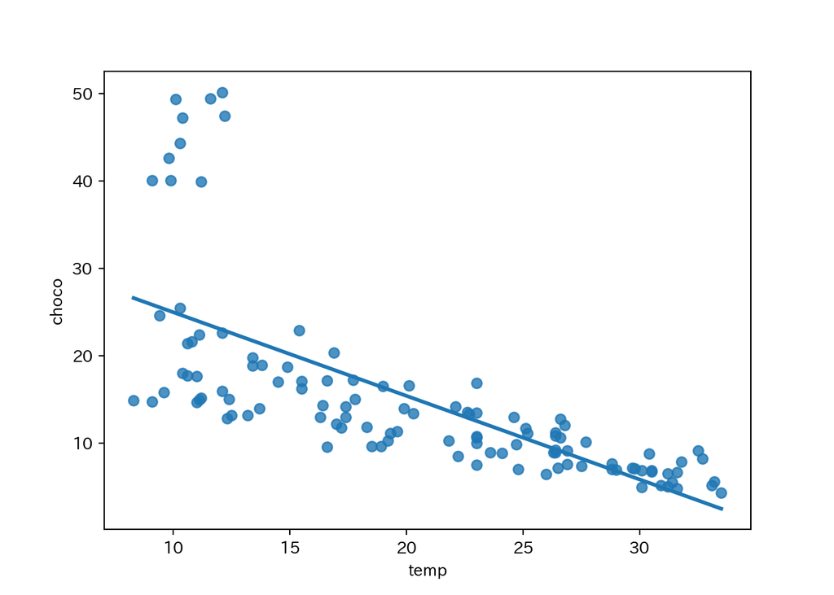

目標が**未来の予測**なら，試みるべきは時系列予測であろう．ここでは，目標が**現象の理解**で，そのための手段が回帰だと考えよう．

**課題** 次の各パターンでの，RMSE（訓練）と $\displaystyle\sqrt{\mathrm{PRESS}/n}$ を求めよ．出力変数は`choco`，モデルは`LinearRegression()`とする．

| パターン | 入力変数 |
| --- | --- |
| 1 | `temp` |
| 2 | `temp`と`feb` |
| 3 | `month` |
| 4 | `month`（ワンホットエンコーディング） |
| 5 | `year`と`month`（いずれもワンホットエンコーディング） |
| 6 | `temp`（そのまま）と，`year`と`month`（いずれもワンホットエンコーディング） |

補足：ここでは，ライブラリの使い方に慣れるために，いろんな変数の組み合わせを，一つずつ確認して練習している．とはいえ，変数が多いときにこの調査を行うのはとても大変だから，通常は，「変数選択」という機械的な方法を用いる．詳細は教科書8.5節を参照．また，`year`や`month`を入力変数とすることを，時系列予測だとみなすなら，交差検証で予測性能を見積もるのは適切ではないのだが，ここでは話を簡単にするために，それについては心配しないこととする．

予測性能が最高なのはどれか，実験する前に予想してみよう．

```python
# 共通部分
X = data3.drop(columns=['choco'])
y = data3['choco']

ss = StandardScaler()
oe = OneHotEncoder(drop='first')
pf = PolynomialFeatures(degree=2, include_bias=False)
pt = 'passthrough'
```

パターン1

```python
# []の部分は無くてもよいが，他のパターンと形を揃えるために残しておく．
ct = ColumnTransformer([
    ('ss', ss, []),
    ('oe', oe, []),
    ('pf', pf, []),
    ('pt', pt, ['temp']),
    ], remainder = 'drop')

pipeline = Pipeline([
    ('ct', ct),
    ('lr', LinearRegression())])

print(TRAIN_RMSE(pipeline, X, y), CV_RMSE(pipeline, X, y))
```

```
## 7.566113543214987 7.730294828739399
```

パターン2

```
## 2.8682514939163704 2.9814680202539443
```

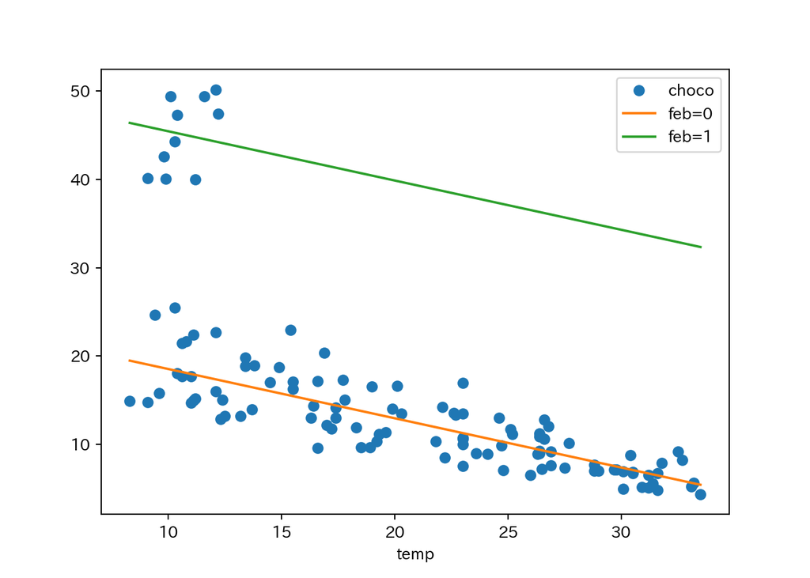

パターン3

```
## 9.553396280313608 9.75411198099738
```

パターン4

```
## 2.6151103595593086 2.9140237187945504
```

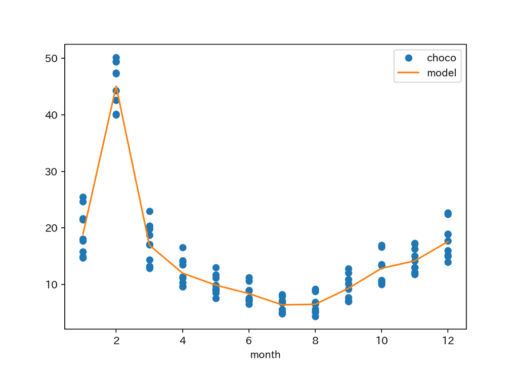

補足：各monthの予測値は，monthごとの平均値である．両者が等しいことを確認する．

```python
pipeline.fit(X, y);

np.allclose(
    pipeline.predict(pd.DataFrame({'month': range(1, 13)})),                 # 各monthの予測値
    data3[['month', 'choco']].groupby('month').mean().values.reshape(1, -1)) # monthごとの平均値
```

```
## True
```

パターン5

```
## 0.9410589441046179 1.1589421728381744
```

パターン6

```
## 0.9406021626279985 1.171727465525522
```

#### 2.3.2 気温とアイスクリーム

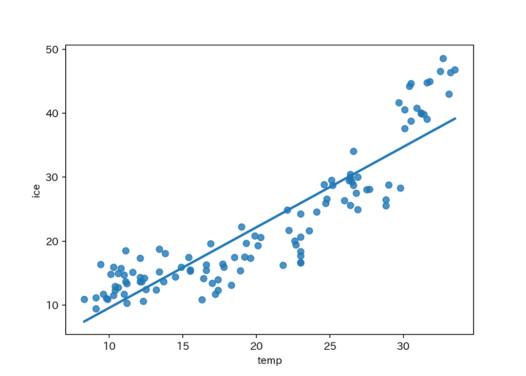

**課題** 次の各パターンでの，RMSE（訓練）と $\displaystyle\sqrt{\mathrm{PRESS}/n}$ を求めよ．出力変数は`ice`，モデルは`LinearRegression()`とする．

| パターン | 入力変数 |
| --- | --- |
| 1 | `temp` |
| 2 | `temp`と`temp`の2乗 |
| 3 | `year`と`month`（ワンホットエンコーディング） |
| 4 | `temp`と`temp`の2乗と，`year`と`month`（ワンホットエンコーディング） |

予測性能が最高なのはどれか，実験する前に予想してみよう．

パターン1

```
## 4.544688870355747 4.63538650170487
```

パターン2

```
## 3.0053915327956804 3.0845901831665152
```

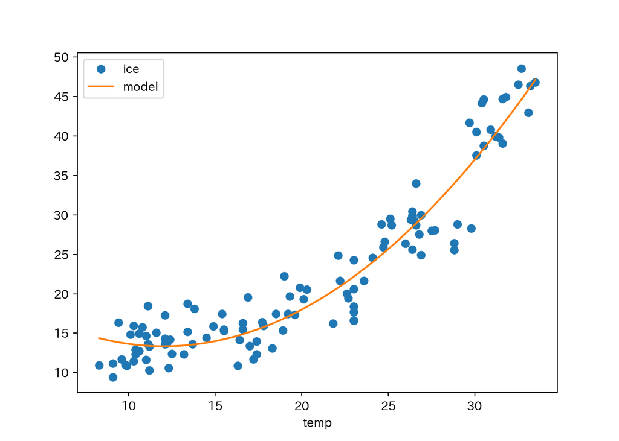

パターン3

```
## 1.2944112519841167 1.5897649379696301
```

パターン4

```
## 0.7986985713803458 1.0118551652845755
```

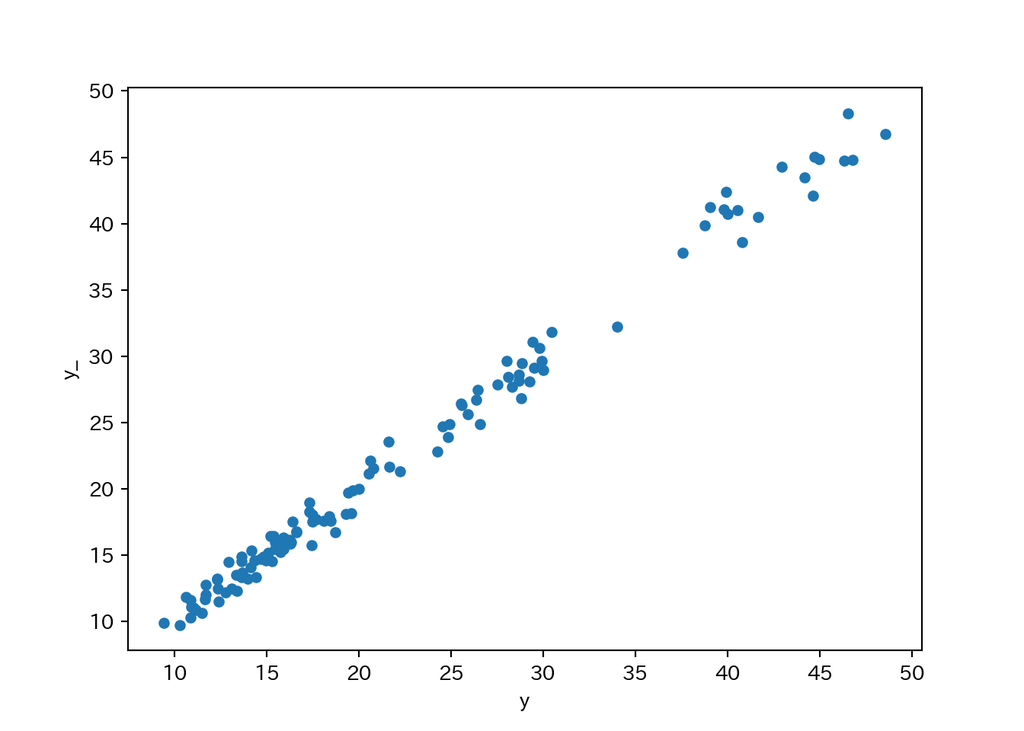

```python
y_ = cross_val_predict(pipeline, X, y, cv=LeaveOneOut())
pd.DataFrame({'y': y, 'y_': y_}).plot.scatter(x='y', y='y_')
```

### 2.4 振り返り

#### 2.4.1 モデルの複雑さと予測性能の関係

##### 2.4.1.1 入力変数の数（教科書8.4節）

`data1`に，0，1の繰り返しからなる変数`v1`と，0，1，2の繰り返しからなる変数`v2`を追加した結果を`data2`とする．

```python
data2 = data1.assign(v1=data1.index % 2, v2=data1.index % 3)
data2.head()
```

```
##    LPRICE2  WRAIN  DEGREES  HRAIN  TIME_SV  v1  v2
## 0 -0.99868    600  17.1167    160       31   0   0
## 1 -0.45440    690  16.7333     80       30   1   1
## 2 -0.80796    502  17.1500    130       28   0   2
## 3 -1.50926    420  16.1333    110       26   1   0
## 4 -1.71655    582  16.4167    187       25   0   1
```

**課題** `data2`に対して線形回帰分析を行った場合のRMSE（訓練）と $\displaystyle\sqrt{\mathrm{PRESS}/n}$ を求めて，`data1`での結果と比較せよ．

##### 2.4.1.2 多項式回帰の次数（教科書7.4.3項）

多項式の次数を高くしても，予測性能は必ずしも良くならない．その理由は過学習が起こるからである．次の例で試す．

```python
data4 = pd.DataFrame({'年齢階級':[35, 45, 55, 65, 75],
                      '血圧の平均':[114, 124, 143, 158, 166]})
```

**課題** 3次式を当てはめる場合の，RMSE（訓練）と $\displaystyle\sqrt{\mathrm{PRESS}/n}$ を求めよ．

補足♠：このデータはサンプルサイズが $5$ だから，当てはめる多項式は3次式までである。4次式にすると，入力変数が多くなり，PRESSを求めるときに，計画行列がフルランクという仮定を満たせなくなる。

RMSE（訓練）と比べて，$\displaystyle\sqrt{\mathrm{PRESS}/n}$ が「かなり」大きいのは，過学習のためである。例えば，LOOCVでやるように，最後のデータを取り除いて，残りの4個のデータで訓練すると，モデルが複雑なため，その4個に合いすぎて，残りの1個でのずれが大きくなる．

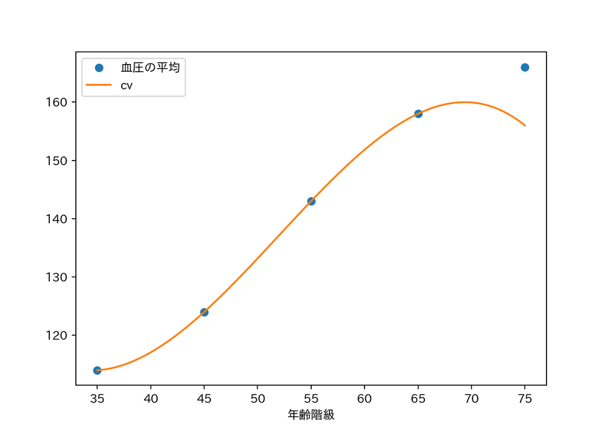

#### 2.4.2 線形回帰分析における標準化の役割♠

計算が正確なら，標準化は線形回帰分析の結果に影響しない（教科書p.234の脚註5）．しかし，浮動小数点数を使う場合は（計算が正確でないため），標準化が線形回帰分析の結果に影響する．次の`data5`で説明する．

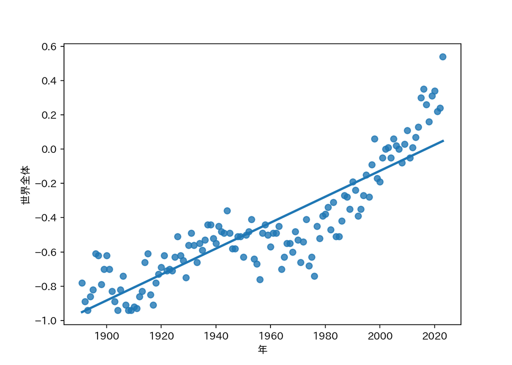

```python
data5 = pd.read_csv('https://www.data.jma.go.jp/cpdinfo/temp/list/csv/an_wld.csv', encoding='Shift_JIS')[['年', '世界全体']]

sns.regplot(data5, x='年', y='世界全体', ci=None);
```

このデータに対して6次の多項式回帰を行うときの $\displaystyle\sqrt{\mathrm{PRESS}/n}$ を求める．

♠概数を求める．これを正解とする．

```python
print(sqrt(N(PRESS) / len(y)))
```

```
## 0.105933090006832
```

標準化せずに，6次の多項式回帰を行う場合，扱う数値は次のようなものである．

```python
pf = PolynomialFeatures(6, include_bias=False)
tmp = pf.fit_transform(data5[['年']])
pd.DataFrame(tmp, columns=pf.get_feature_names_out(['年'])).head()
```

```
##         年        年^2           年^3           年^4           年^5           年^6
## 0  1891.0  3575881.0  6.761991e+09  1.278692e+13  2.418008e+16  4.572452e+19
## 1  1892.0  3579664.0  6.772724e+09  1.281399e+13  2.424408e+16  4.586979e+19
## 2  1893.0  3583449.0  6.783469e+09  1.284111e+13  2.430822e+16  4.601545e+19
## 3  1894.0  3587236.0  6.794225e+09  1.286826e+13  2.437249e+16  4.616149e+19
## 4  1895.0  3591025.0  6.804992e+09  1.289546e+13  2.443690e+16  4.630792e+19
```

**課題** （標準化なし）`data5`に対して，6次の多項式回帰を行い，$\displaystyle\sqrt{\mathrm{PRESS}/n}$ を求めよ（結果は妥当ではない）．

標準化して，6次の多項式回帰を行う場合，扱う数値は次のようなものである．

```python
ss = StandardScaler()
tmp = pf.fit_transform(ss.fit_transform(data5[['年']]))
pd.DataFrame(tmp, columns=pf.get_feature_names_out(['年'])).head()
```

```
##           年       年^2       年^3       年^4        年^5        年^6
## 0 -1.719076  2.955224 -5.080256  8.733348 -15.013293  25.808999
## 1 -1.693030  2.866350 -4.852816  8.215963 -13.909870  23.549825
## 2 -1.666983  2.778833 -4.632268  7.721913 -12.872300  21.457909
## 3 -1.640937  2.692673 -4.418506  7.250488 -11.897591  19.523193
## 4 -1.614890  2.607870 -4.211423  6.800985 -10.982842  17.736082
```

**課題** （標準化あり）`data5`に対して，6次の多項式回帰を行い，$\displaystyle\sqrt{\mathrm{PRESS}/n}$ を求めよ。

**課題** （時間に余裕がある場合）生成AIで全てをやり直せ．